# 06-ds4ps-inference-assignment

Geórgia Ribeiro

26-04-2022

# 1 Valendo-se dos dados do World Values Survey, `EVS_WVS_Cross-National_Wave_7_joint_core_R_v1_1.rds`, responda: qual é o percentual de pessoas que confia em partidos políticos na Argentina? Você diria que o número é estatisticamente diferente do que observamos Brasil?

**Dica:** O livro de códigos está disponível na pasta `data`.

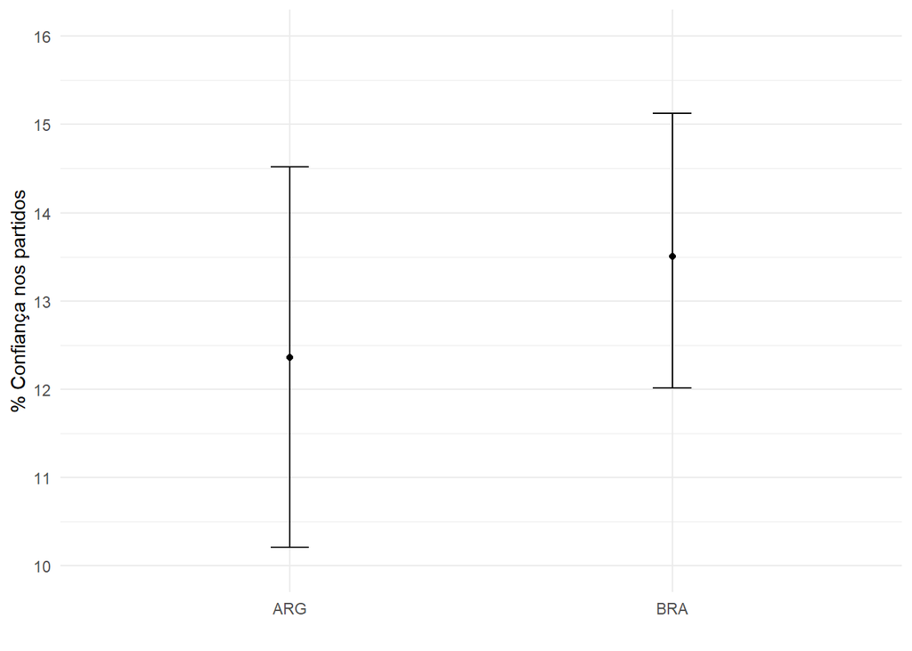

```r
#carregar banco
wvs = tibble(readRDS(here("./data/EVS_WVS_Cross-National_Wave_7_joint_core_R_v1_1.rds")))

## calcular Argentina
partidos_bootstrap_arg = wvs %>%
 select(C_COW_ALPHA, A_YEAR, Q72) %>%  filter(C_COW_ALPHA == "ARG") %>%
 mutate(confia_em_partidos = case_when(Q72 %in% c(1, 2) ~ 1,TRUE ~ 0)) %>%
 specify(response = confia_em_partidos) %>%
 generate(reps = 1000, type = "bootstrap") %>%
 calculate(stat = "mean")

ci_se_arg = partidos_bootstrap_arg %>%
 get_confidence_interval(type = "se", point_estimate = mean(partidos_bootstrap_arg$stat))
#partidos_bootstrap_arg %>%  visualize() + shade_confidence_interval(endpoints = ci_se_arg)

## calcular Brasil
partidos_bootstrap_bra = wvs %>%
 select(C_COW_ALPHA, A_YEAR, Q72) %>% filter(C_COW_ALPHA == "BRA") %>%
 mutate(confia_em_partidos = case_when(Q72 %in% c(1, 2) ~ 1,TRUE ~ 0)) %>%
 specify(response = confia_em_partidos) %>%
 generate(reps = 1000, type = "bootstrap") %>%
 calculate(stat = "mean")

ci_se_bra = partidos_bootstrap_bra %>%
 get_confidence_interval(type = "se", point_estimate = mean(partidos_bootstrap_bra$stat))
#partidos_bootstrap_bra %>%  visualize() + shade_confidence_interval(endpoints = ci_se_bra)

## comparacao
mean_partidos = wvs %>%
 select(C_COW_ALPHA, A_YEAR, Q72) %>% filter (C_COW_ALPHA == "BRA" | C_COW_ALPHA == "ARG") %>%
 mutate(confia_em_partidos = case_when(Q72 %in% c(1, 2) ~ 1,TRUE ~ 0)) %>%
  group_by(C_COW_ALPHA, confia_em_partidos) %>%
  summarise(n = n()) %>%
  mutate(perc_confia = n/sum(n)) %>%
   filter(confia_em_partidos == 1) %>%
   select(C_COW_ALPHA, perc_confia)

ci_se_arg = ci_se_arg %>% mutate(C_COW_ALPHA = "ARG")
ci_se_bra = ci_se_bra %>% mutate(C_COW_ALPHA = "BRA")
ci_se = rbind(ci_se_arg, ci_se_bra)

df_compare = left_join(mean_partidos, ci_se, by='C_COW_ALPHA') %>% mutate_if(is.numeric, ~ . * 100)

df_compare %>% ggplot(aes(x=C_COW_ALPHA, y=perc_confia)) +
  geom_errorbar(aes(ymin=lower_ci, ymax=upper_ci), width=.1) +
  geom_point() +
  scale_y_continuous(limits = c(10, 16), breaks = seq(10, 16, by = 1)) +
  theme_minimal() +
  labs(x= '', y= '% Confiança nos partidos')
```

*Resposta:* 12.36% dos argentinos confiam em partidos políticos. O resultado não é estatisticamente diferente do que observamos Brasil, cujo resultado indica que 13.51% da população confia nos partidos, visto que o intervalo de confiança (IC) de ambas as médias se intercalam e são capazes de incluir o parâmetro real das populações em cerca de 95% do tempo. O gráfico acima ilustra as estimativas intervalares da Argentina e do Brasil.

# 2 Identifique o país com maior nível de desconfiança na Imprensa, e construa o intervalo de 95% de confiança em torno da média.

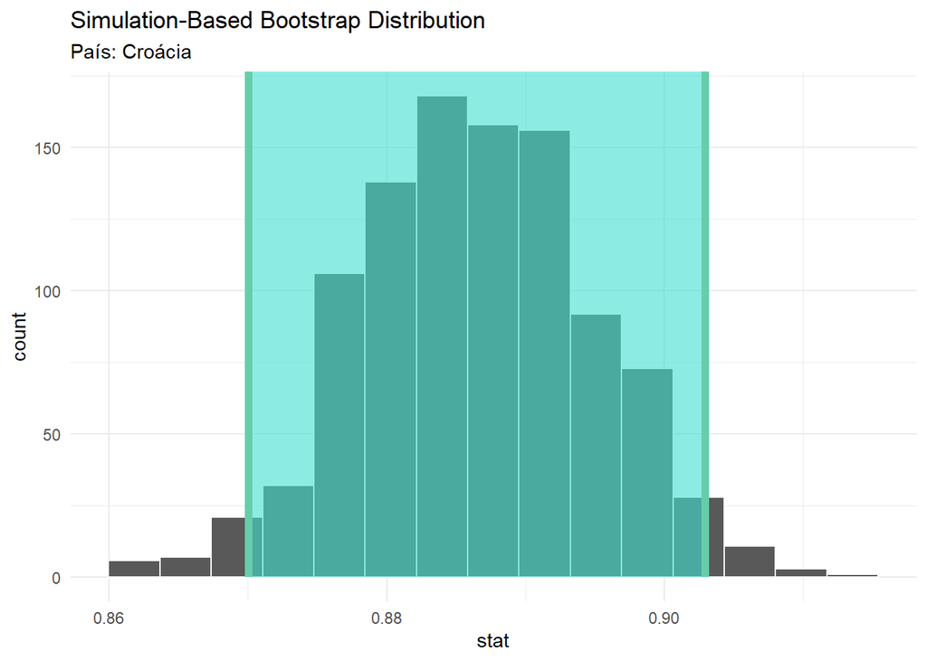

```r
## maior desconfiança
desconfianca_respostas = wvs %>%
  select(C_COW_ALPHA, A_YEAR, Q66) %>%
  mutate(desconfia_imprensa = case_when(Q66 %in% c(3, 4) ~ 1,TRUE ~ 0)) %>%
  group_by(C_COW_ALPHA, desconfia_imprensa) %>%
  summarise(n = n()) %>%
  mutate(perc_desconfia = round(n/sum(n),2)) %>%
  select(C_COW_ALPHA, perc_desconfia) %>%
  arrange(desc(perc_desconfia))

## calcular intervalo de confiança Croacia
desconfianca_bootstrap = wvs %>%
 select(C_COW_ALPHA, A_YEAR, Q66) %>%
 filter(C_COW_ALPHA == "CRO") %>%
 mutate(desconfia_imprensa = case_when(Q66 %in% c(3, 4) ~ 1,TRUE ~ 0)) %>%
 specify(response = desconfia_imprensa) %>%
 generate(reps = 1000, type = "bootstrap") %>%
 calculate(stat = "mean")

ci_se = desconfianca_bootstrap %>%
 get_confidence_interval(type = "se", point_estimate = mean(desconfianca_bootstrap$stat))

desconfianca_bootstrap %>%  visualize() +
  shade_confidence_interval(endpoints = ci_se) +
  labs(subtitle = "País: Croácia") +
  theme_minimal()
```

# 3 Escreva uma frase interpretando as estimativas encontradas na pergunta 2. Os valores da média e do intervalo de confiança devem ser reportados de maneira dinâmica, embutidos no seu texto, por meio de objetos que você criou na pergunta anterior.

*Resposta:* O país que mais desconfia da imprensa é a Croácia, com 89% das respostas sendo “Não tenho muita confiança” ou “Não tenho nenhuma confiança”. Definindo o nível de confiança de 95%, a estimativa de desconfiança da população está entre 87% e 90.3%.

# 4 Valendo-se dos dados do World Values Survey, responda: qual é o percentual de pessoas que confia nos tribunais na Argentina? E no Brasil? Você diria que o número é estatisticamente diferente do que observamos no Brasil? Escreva uma frase interpretando as estimativas encontradas. Os valores da média e do intervalo de confiança devem ser reportados de maneira dinâmica, embutidos no seu texto, por meio de objetos que você criou ao realizar os cálculos.

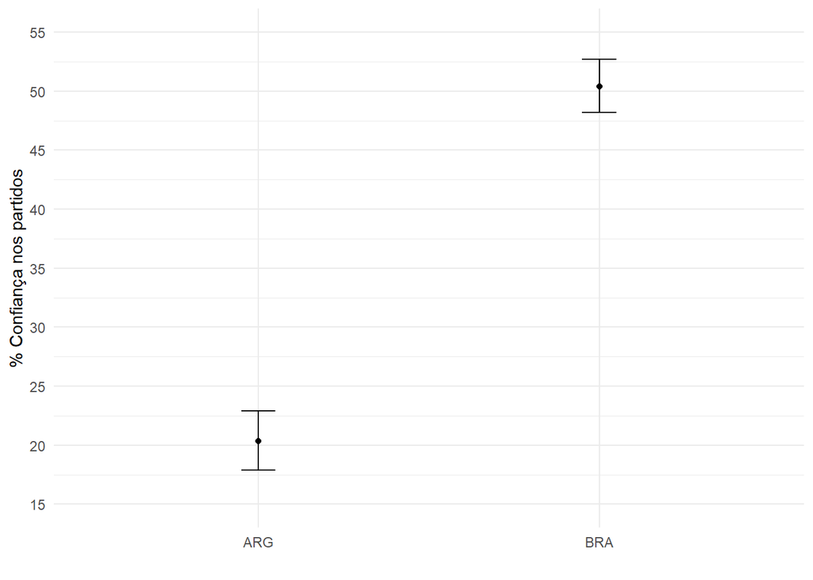

```r
## calcular Argentina
tribunais_bootstrap_arg = wvs %>%
 select(C_COW_ALPHA, A_YEAR, Q70) %>%  filter(C_COW_ALPHA == "ARG") %>%
 mutate(confia_em_tribunais = case_when(Q70 %in% c(1, 2) ~ 1,TRUE ~ 0)) %>%
 specify(response = confia_em_tribunais) %>%
 generate(reps = 1000, type = "bootstrap") %>%
 calculate(stat = "mean")

ci_se_arg = tribunais_bootstrap_arg %>%
 get_confidence_interval(type = "se", point_estimate = mean(tribunais_bootstrap_arg$stat))

## calcular Brasil
tribunais_bootstrap_bra = wvs %>%
 select(C_COW_ALPHA, A_YEAR, Q70) %>% filter(C_COW_ALPHA == "BRA") %>%
 mutate(confia_em_tribunais = case_when(Q70 %in% c(1, 2) ~ 1,TRUE ~ 0)) %>%
 specify(response = confia_em_tribunais) %>%
 generate(reps = 1000, type = "bootstrap") %>%
 calculate(stat = "mean")

ci_se_bra = tribunais_bootstrap_bra %>%
 get_confidence_interval(type = "se", point_estimate = mean(tribunais_bootstrap_bra$stat))

## comparacao
mean_tribunais = wvs %>%
 select(C_COW_ALPHA, A_YEAR, Q70) %>% filter (C_COW_ALPHA == "BRA" | C_COW_ALPHA == "ARG") %>%
 mutate(confia_em_tribunais = case_when(Q70 %in% c(1, 2) ~ 1,TRUE ~ 0)) %>%
  group_by(C_COW_ALPHA, confia_em_tribunais) %>%
  summarise(n = n()) %>%
  mutate(perc_confia = n/sum(n)) %>%
   filter(confia_em_tribunais == 1) %>%
   select(C_COW_ALPHA, perc_confia)

ci_se_arg = ci_se_arg %>% mutate(C_COW_ALPHA = "ARG")
ci_se_bra = ci_se_bra %>% mutate(C_COW_ALPHA = "BRA")
ci_se = rbind(ci_se_arg, ci_se_bra)

df_compare = left_join(mean_tribunais, ci_se, by='C_COW_ALPHA') %>% mutate_if(is.numeric, ~ . * 100)


df_compare %>% ggplot(aes(x=C_COW_ALPHA, y=perc_confia)) +
  geom_errorbar(aes(ymin=lower_ci, ymax=upper_ci), width=.1) +
  geom_point() +
  scale_y_continuous(limits = c(15, 55), breaks = seq(15, 55, by = 5)) +
  theme_minimal() +
  labs(x= '', y= '% Confiança nos partidos')
```

*Resposta:* Na Argentina, 20.34% das pessoas confiam nos tribunais na Argentina. Já no Brasil, o resultado é mais positivo, com 50.4% dos respondentes confiantes a respeito dos tribunais. Os resultados da pesquisa são estatisticamente diferentes, considerando que as estimativas intervalares dos países possuem valores distantes, calculadas com o nível de confiança de 95%. Isto é, repetindo a pesquisa infinitas vezes, 95% das médias da população da argentina estariam entre 17.88% e 22.89% e para o Brasil, estariam entre 48.18% e 52.71%.

# 5 Produza um documento .html que apresente seu código com o resultado de sua análise.

Documento HTML

**Observação**: Não se esqueça de colocar seu nome.